# Reproducible Research: Peer Assessment 1

## Loading and preprocessing the data

**1. Loading the data** Here i load the data into R.

```r
data <- read.csv('activity.csv')
```

**2. Process/transform the data (if necessary) into a format suitable for your analysis** I process the date to be able to work with it using lubridate package

```r
data$date<-ymd(data$date) # Using lubridate
data$dayweek <- wday(data$date, label=TRUE)
summary(data)
```

```
##      steps             date               interval      dayweek
##  Min.   :  0.00   Min.   :2012-10-01   Min.   :   0.0   Sun:2304
##  1st Qu.:  0.00   1st Qu.:2012-10-16   1st Qu.: 588.8   Mon:2592
##  Median :  0.00   Median :2012-10-31   Median :1177.5   Tue:2592
##  Mean   : 37.38   Mean   :2012-10-31   Mean   :1177.5   Wed:2592
##  3rd Qu.: 12.00   3rd Qu.:2012-11-15   3rd Qu.:1766.2   Thu:2592
##  Max.   :806.00   Max.   :2012-11-30   Max.   :2355.0   Fri:2592
##  NA's   :2304                                           Sat:2304
```

## What is mean total number of steps taken per day?

**1. Calculate the total number of steps taken per day** Here i calculate the total steps by date.

```r
total_steps <- data %>% group_by(date) %>% summarise(sum(steps, na.rm = TRUE))
```

**2. Make a histogram of the total number of steps taken each day**

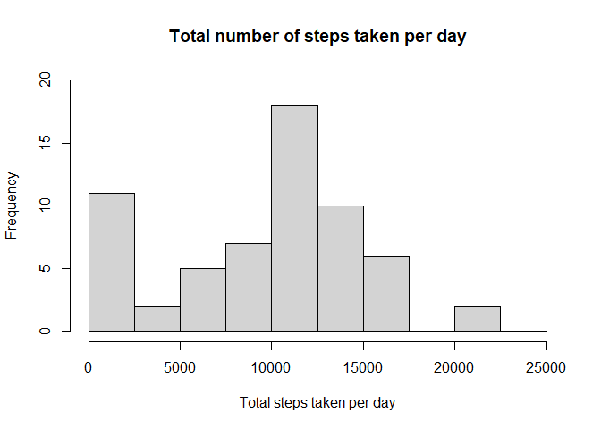

```r
names(total_steps) <- c("date", "steps")
hist(total_steps$steps, ylim = c(0,20), breaks = seq(0,25000, by=2500), main = "Total number of steps taken per day", xlab = "Total steps taken per day")
```

**3. Calculate and report the mean and median of the total number of steps taken per day** The Mean and Median for the total steps are

```r
## Mean
mean(total_steps$steps)
```

```
## [1] 9354.23
```

```r
## Median
median(total_steps$steps)
```

```
## [1] 10395
```

## What is the average daily activity pattern?

**1. Make a time series plot of the 5-minute interval (x-axis) and the average number of steps taken, averaged across all days (y-axis)**

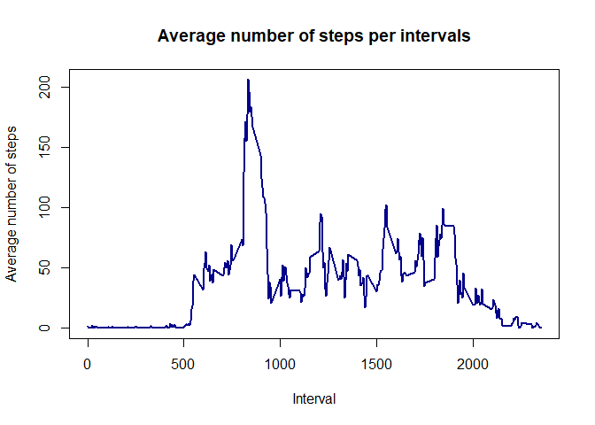

```r
avg_daily_pattern <- data %>% group_by(interval) %>% summarise(mean(steps, na.rm = TRUE))
names(avg_daily_pattern) <- c("interval", "mean")
plot(avg_daily_pattern$interval, avg_daily_pattern$mean, type = "l", col="darkblue", lwd = 2, xlab="Interval", ylab="Average number of steps", main="Average number of steps per intervals")
```

**2. Which 5-minute interval, on average across all the days in the dataset, contains the maximum number of steps?** The interval with the maximun number of steps is

```r
## Maximun Number of steps
avg_daily_pattern[which.max(avg_daily_pattern$mean), ]$interval
```

```
## [1] 835
```

## Imputing missing values

**1. Calculate and report the total number of missing values in the dataset (i.e. the total number of rows with NA’s)** The total number of na’s is

```r
## Total Na's
sum(is.na(data$steps))
```

```
## [1] 2304
```

**2. Devise a strategy for filling in all of the missing values in the dataset. The strategy does not need to be sophisticated. For example, you could use the mean/median for that day, or the mean for that 5-minute interval, etc** Imputing the na’s with the average daily pattern for that interval(mean of the steps by interval)

```r
imputed_steps <- avg_daily_pattern$mean[match(data$interval, avg_daily_pattern$interval)]
```

**3. Create a new dataset that is equal to the original dataset but with the missing data filled in.**

```r
data_imputed <- transform(data, steps = ifelse(is.na(data$steps), yes = imputed_steps, no = data$steps))
```

**4. Make a histogram of the total number of steps taken each day and Calculate and report the mean and median total number of steps taken per day. Do these values differ from the estimates from the first part of the assignment? What is the impact of imputing missing data on the estimates of the total daily number of steps?**

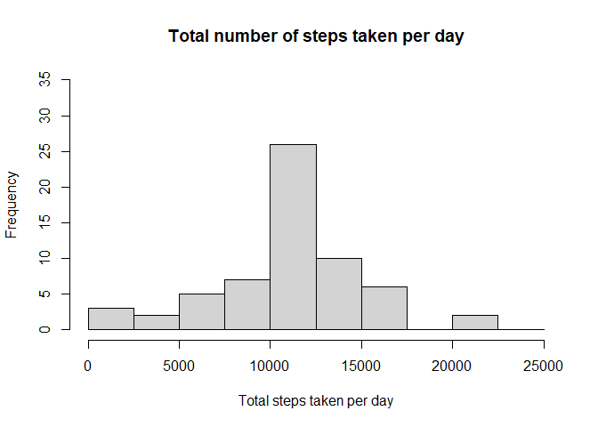

```r
total_steps_imputed <- data_imputed %>% group_by(date) %>% summarise(sum(steps, na.rm = TRUE))
names(total_steps_imputed) <- c("date", "steps")
hist(total_steps_imputed$steps, ylim = c(0,35), breaks = seq(0,25000, by=2500), main = "Total number of steps taken per day", xlab = "Total steps taken per day")
```

As we can see the distribution is normal as the mean and median are the same, with na’s there was a slight difference since a concentration of the values where Na’s

```r
## Mean with Na's
mean(total_steps$steps)
```

```
## [1] 9354.23
```

```r
## Mean Imputed
mean(total_steps_imputed$steps)
```

```
## [1] 10766.19
```

```r
## Median with Na's
median(total_steps$steps)
```

```
## [1] 10395
```

```r
## Median Imputed
median(total_steps_imputed$steps)
```

```
## [1] 10766.19
```

## Are there differences in activity patterns between weekdays and weekends?

**1. Create a new factor variable in the dataset with two levels – “weekday” and “weekend” indicating whether a given date is a weekday or weekend day.**

```r
data_imputed$date<-ymd(data_imputed$date) # Using lubridate
data_imputed <- mutate(data_imputed, day_type = ifelse(weekdays(date) == "Saturday" | weekdays(date) =="Sunday", "Weekend", "Weekday"))
data_imputed$day_type <- as.factor(data_imputed$day_type)
summary(data_imputed)
```

```
##      steps             date               interval      dayweek
##  Min.   :  0.00   Min.   :2012-10-01   Min.   :   0.0   Sun:2304
##  1st Qu.:  0.00   1st Qu.:2012-10-16   1st Qu.: 588.8   Mon:2592
##  Median :  0.00   Median :2012-10-31   Median :1177.5   Tue:2592
##  Mean   : 37.38   Mean   :2012-10-31   Mean   :1177.5   Wed:2592
##  3rd Qu.: 27.00   3rd Qu.:2012-11-15   3rd Qu.:1766.2   Thu:2592
##  Max.   :806.00   Max.   :2012-11-30   Max.   :2355.0   Fri:2592
##                                                         Sat:2304
##     day_type
##  Weekday:12960
##  Weekend: 4608
##
##
##
##
##
```

**2. Make a panel plot containing a time series plot of the 5-minute interval (x-axis) and the average number of steps taken, averaged across all weekday days or weekend days (y-axis).** As we can se the weekdays have a peak in the morning and stays lower throughout the day while in the weekends, though not as high it variates slightly throuout the day.

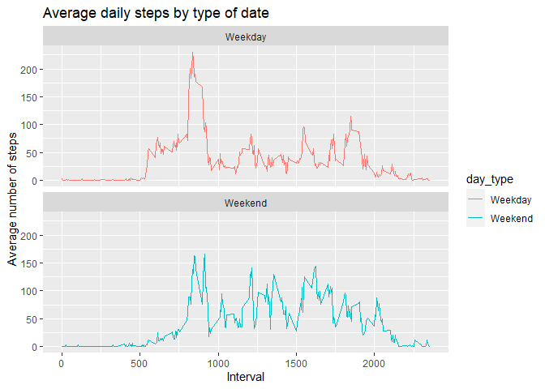

```r
activity_by_date <- data_imputed %>% group_by(interval, day_type) %>% summarise( steps = mean(steps))

plot<- ggplot(activity_by_date, aes(x = interval , y = steps, color = day_type)) +
       geom_line() +
       labs(title = "Average daily steps by type of date", x = "Interval", y = "Average number of steps") +
       facet_wrap(~day_type, ncol = 1, nrow=2)
print(plot)
```